# Displaying graphs

For displaying graphs we shall need the module `matplotlib.pyplot`. We upload the dataFrames we saved in the previous notebook.

```python
import numpy as np
import pandas as pd
import matplotlib.pyplot as plt
import statmodules.tables as tab
```

## Categorical variable

If you have saved correctly the frequency table of the variable `cartel` as

```python
xtab = pd.read_csv('cartelStability/table_cartel.csv', index_col = 0)
xtab
```

|  | frequencies | relative frequencies |
| --- | --- | --- |
| no | 125.0 | 0.381098 |
| yes | 203.0 | 0.618902 |

then the `bar`and `barh` commands will display the graphs with what you first saved as index (here `no` and `yes`).

```python
ni = np.array(xtab['frequencies'][:])
ni
```

```
array([125., 203.])
```

```python
fi = np.array(xtab['relative frequencies'][:])
fi
```

```
array([0.38109756, 0.61890244])
```

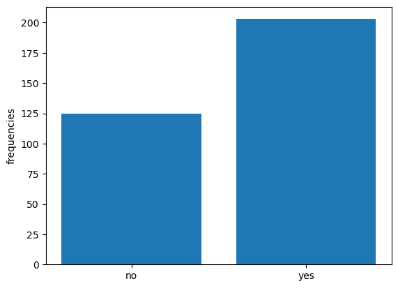

```python
plt.bar(xtab.index, ni)
plt.ylabel('frequencies')
plt.show()
```

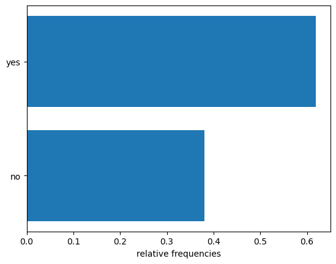

```python
plt.barh(xtab.index, fi)
plt.xlabel('relative frequencies')
plt.show()
```

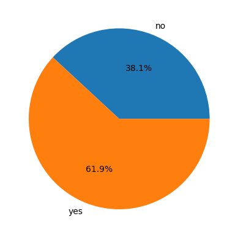

```python
plt.pie(ni, labels = xtab.index, autopct='%1.1f%%') # even with the ni you plot the fi
plt.show()
```

## Discrete variable

For discrete variable, the `index` column does not necessarily contain the values of the variable. If not, we have to create the `index` column with the proper dataFrame column (here, the first column, numbered 0).

```python
ytab = pd.read_csv('cartelStability/table_price.csv', index_col = 0)
ytab
```

|  | frequencies | relative frequencies | cumulative relative frequencies |
| --- | --- | --- | --- |
| 0.125 | 10.0 | 0.030488 | 0.030488 |
| 0.150 | 52.0 | 0.158537 | 0.189024 |
| 0.200 | 49.0 | 0.149390 | 0.338415 |
| 0.250 | 106.0 | 0.323171 | 0.661585 |
| 0.300 | 76.0 | 0.231707 | 0.893293 |
| 0.350 | 26.0 | 0.079268 | 0.972561 |
| 0.400 | 9.0 | 0.027439 | 1.000000 |

### Bar and line graphs for frequencies or relative frequencies

```python
ni = np.array(ytab['frequencies'][:])
fi = np.array(ytab['relative frequencies'][:])
```

But then while displaying the bar graph, we do not get what we expect:

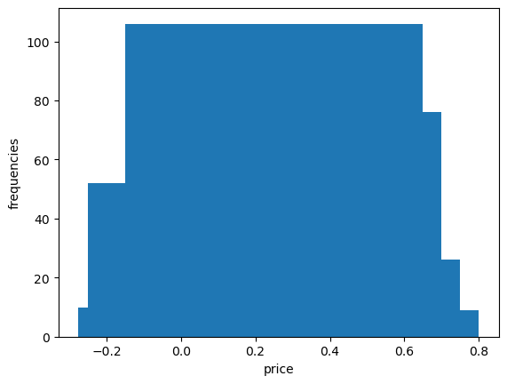

```python
plt.bar(ytab.index, ni)
plt.ylabel('frequencies')
plt.xlabel('price')
plt.show()
```

It looks more like an histogram than like a bar graph and the values are quite inexpected! This is due to the fact that the bars are far too large (default is 0.8 and we choose a lot less):

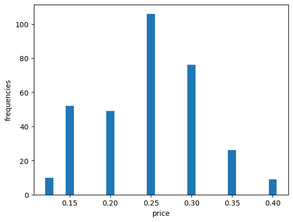

```python
plt.bar(ytab.index, ni, width = 0.01)
plt.ylabel('frequencies')
plt.xlabel('price')
plt.show()
```

If we want to display all value names, we need to place them at the right place:

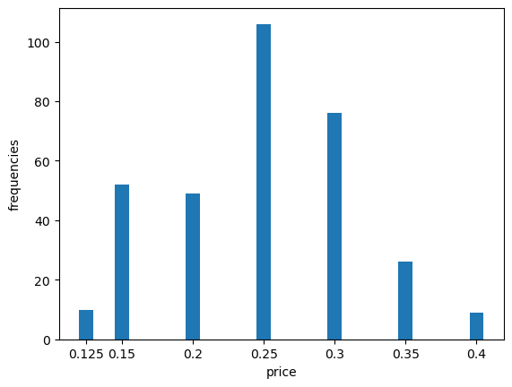

```python
plt.bar(ytab.index, ni, width = 0.01)
plt.xticks(ytab.index, ytab.index) # the first argument is the vecor of positions, the second the vector of names
plt.ylabel('frequencies')
plt.xlabel('price')
plt.show()
```

The associated line graph, displayed here for relative frequencies:

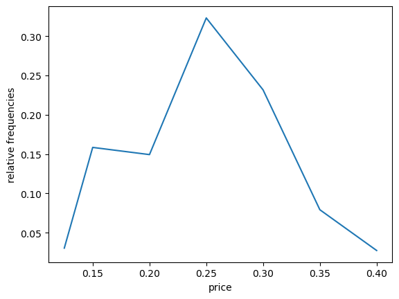

```python
plt.plot(ytab.index, fi)
plt.ylabel('relative frequencies')
plt.xlabel('price')
plt.show()
```

### Representation of the cumulative relative frequency

```python
Fi = np.array(ytab['cumulative relative frequencies'][:])
Fi
```

```
array([0.0304878 , 0.18902439, 0.33841463, 0.66158537, 0.89329268,
       0.97256098, 1.        ])
```

We complete $F_i$ with a 0 at position 0 because the cumulative frequencies, when represented as a function (the eCDF) goes from 0 to 1.

```python
Fi_comp = np.insert(Fi, 0, 0) #
Fi_comp, len(Fi_comp)
```

```
(array([0.        , 0.0304878 , 0.18902439, 0.33841463, 0.66158537,
        0.89329268, 0.97256098, 1.        ]),
 8)
```

The $F_i$ change at each value of the variable ($a_i$ in the lecture):

```python
ytab.index, len(ytab.index)
```

```
(Index([0.125, 0.15, 0.2, 0.25, 0.3, 0.35, 0.4], dtype='float64'), 7)
```

We complete this vector by choosing a minimal and maximal values for the $x$-axis. Here for instance 0 and 0.5.

```python
edges = np.insert(ytab.index, 0, 0) # at the biginning of the vector
edges = np.append(edges, 0.5) # at the end of the vector
edges, len(edges)
```

```
(array([0.   , 0.125, 0.15 , 0.2  , 0.25 , 0.3  , 0.35 , 0.4  , 0.5  ]), 9)
```

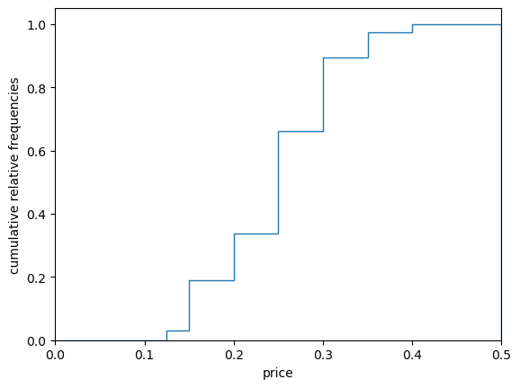

```python
plt.stairs(Fi_comp,edges)
plt.xlim(0,0.5)
plt.ylabel('cumulative relative frequencies')
plt.xlabel('price')
plt.show()
```

## Continuous variable

Here we only display histograms, the boxplot will come at the end of the next notebook.

```python
ztab = pd.read_csv('cartelStability/table_quantity.csv', index_col = 0)
ztab
```

|  | lo | hi | frequencies | relative frequencies | cumulative relative frequencies |
| --- | --- | --- | --- | --- | --- |
| 0 | 0.0 | 8000.0 | 6.0 | 0.018293 | 0.018293 |
| 1 | 8000.0 | 12000.0 | 26.0 | 0.079268 | 0.097561 |
| 2 | 12000.0 | 16000.0 | 41.0 | 0.125000 | 0.222561 |
| 3 | 16000.0 | 20000.0 | 48.0 | 0.146341 | 0.368902 |
| 4 | 20000.0 | 24000.0 | 57.0 | 0.173780 | 0.542683 |
| 5 | 24000.0 | 28000.0 | 31.0 | 0.094512 | 0.637195 |
| 6 | 28000.0 | 32000.0 | 36.0 | 0.109756 | 0.746951 |
| 7 | 32000.0 | 36000.0 | 25.0 | 0.076220 | 0.823171 |
| 8 | 36000.0 | 40000.0 | 22.0 | 0.067073 | 0.890244 |
| 9 | 40000.0 | 44000.0 | 15.0 | 0.045732 | 0.935976 |
| 10 | 44000.0 | 52000.0 | 12.0 | 0.036585 | 0.972561 |
| 11 | 52000.0 | 80000.0 | 9.0 | 0.027439 | 1.000000 |

### Completing the table

In order to draw the histogram, we need two more columns, namely the column with the classes'width and the column with the bar's heights.

```python
fi = np.array(ztab['relative frequencies'][:])
lo = np.array(ztab['lo'])
hi = np.array(ztab['hi'])
```

```python
width = hi-lo  # vector of classes' widths
height = fi/width # vector of classes' heights
height
```

```
array([2.28658537e-06, 1.98170732e-05, 3.12500000e-05, 3.65853659e-05,
       4.34451220e-05, 2.36280488e-05, 2.74390244e-05, 1.90548780e-05,
       1.67682927e-05, 1.14329268e-05, 4.57317073e-06, 9.79965157e-07])
```

For drawing command, we need the complete bins lists by adding to `lo` the last element of `hi`:

```python
bin_edges = np.append(lo,hi[-1])
bin_edges
```

```
array([    0.,  8000., 12000., 16000., 20000., 24000., 28000., 32000.,
       36000., 40000., 44000., 52000., 80000.])
```

We finally draw the histogram. Note that the first argument contains the lower bounds of the intervals while the second is the complete list of the bins.

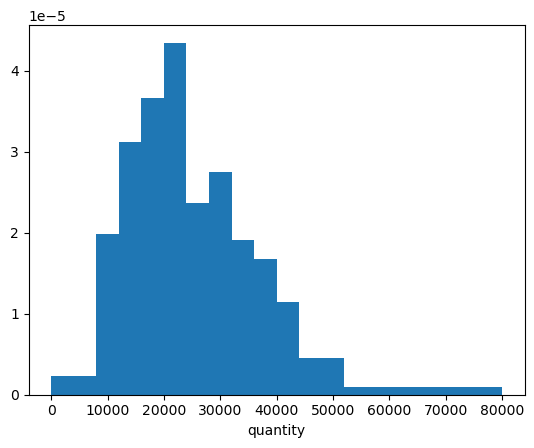

```python
plt.hist(bin_edges[:-1], bins = bin_edges, weights = height)
plt.xlabel('quantity')
plt.show()
```